# **Implementación de Algoritmos MCMC**

## **Curso: Modelos Avanzados en Estadística Bayesiana**

### Doctorando: Antonio Lam

### Profesor: Dr. Erick Chacón

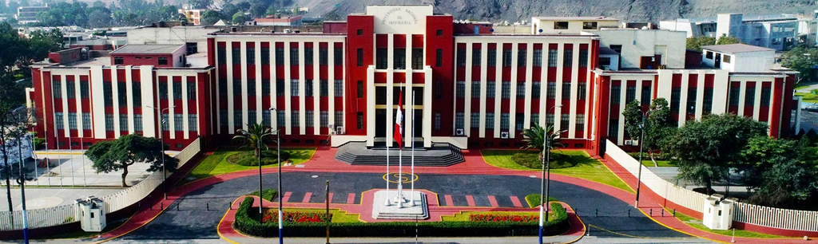

```julia
using Distributions
using Plots
using Random
using Statistics
using StatsPlots
using KernelDensity
using StatsBase
using MCMCChains
using LaTeXStrings
```

# **Caso 1: Algoritmo Cero Inflado - Zero Inflated**

```
Datos generados: n = 200
Verdaderos: π = 0.4, λ = 2.5
Proporción empírica de ceros: 0.4
Media de los no ceros: 2.6666666666666665
```

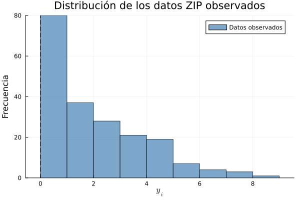

```julia
# ------------------------------------------------------------
# Celda 2: Definir modelo ZIP y generar datos sintéticos
# ------------------------------------------------------------
# Parámetros verdaderos
π_true = 0.4          # Probabilidad de cero estructural
λ_true = 2.5          # Tasa del proceso Poisson
n = 200               # Tamaño de muestra

# Función para generar datos ZIP
function generate_zip(n, π, λ)
    y = zeros(Int, n)
    for i in 1:n
        if rand() < π
            y[i] = 0               # Cero estructural
        else
            y[i] = rand(Poisson(λ))  # Proceso de conteo
        end
    end
    return y
end

# Generar datos
y_obs = generate_zip(n, π_true, λ_true)

# Mostrar resumen
println("Datos generados: n = $n")
println("Verdaderos: π = $π_true, λ = $λ_true")
println("Proporción empírica de ceros: $(mean(y_obs .== 0))")
println("Media de los no ceros: $(mean(y_obs[y_obs .> 0]))")

# Visualización: histograma de datos observados
histogram(y_obs, bins=0:maximum(y_obs)+1,
          label="Datos observados",
          xlabel=L"y_i", ylabel="Frecuencia",
          title="Distribución de los datos ZIP observados",
          alpha=0.7, color=:steelblue)
vline!([0], label="", color=:black, linestyle=:dash)
```

```julia
# ------------------------------------------------------------
# Celda 3: Algoritmo Gibbs Sampling para ZIP (sin covariables)
# ------------------------------------------------------------
function gibbs_zip(y, α0, β0, λ0; n_iter=5000, burn_in=1000)
    n = length(y)
    n0 = sum(y .== 0)
    n_pos = n - n0

    # Inicialización
    π_samples = Float64[]
    λ_samples = Float64[]
    δ_sum = 0  # número total de ceros estructurales

    π = 0.5
    λ = λ0

    for iter in 1:n_iter
        # Paso 1: Muestrear δ_i para cada y_i = 0
        δ_sum = 0
        for i in 1:n
            if y[i] == 0
                p_struct = π
                p_poisson_zero = (1 - π) * pdf(Poisson(λ), 0)
                prob_struct = p_struct / (p_struct + p_poisson_zero)
                δ = rand() < prob_struct ? 1 : 0
                δ_sum += δ
            end
        end

        # Paso 2: Muestrear π | δ ~ Beta(α0 + S, β0 + n0 - S + n_pos)
        π = rand(Beta(α0 + δ_sum, β0 + (n0 - δ_sum) + n_pos))

        # Paso 3: Muestrear λ | y, δ
        # Dado que los no ceros vienen del Poisson, y los ceros no estructurales también,
        # la verosimilitud de λ depende de todos los datos (incluyendo ceros no estructurales).
        # Pero como no sabemos cuáles ceros son del Poisson, usamos el hecho de que
        # la suma total de conteos es suficiente para λ si supiéramos todos los datos del Poisson.
        # Sin embargo, en Gibbs con variables latentes, solo los no ceros son observaciones "visibles"
        # del Poisson; los ceros no estructurales también contribuyen, pero están integrados.
        # Enfoque aproximado común: usar solo los no ceros y asumir que los ceros no estructurales
        # ya están contabilizados en la parte de π. Alternativamente, se puede usar un prior conjugado.

        # Usamos prior Gamma(a,b) para λ → posterior Gamma(a + sum(y), b + n_effective)
        # Pero sin covariables y con δ, el número efectivo de observaciones del Poisson es:
        # n_poisson = n_pos + (n0 - δ_sum)  → pero no observamos los valores de los ceros no estructurales
        # Por simplicidad (y práctica común), asumimos que la media de Poisson se estima solo con no ceros.
        # Mejor: usamos un paso de Metropolis o prior no conjugado. Aquí usamos Gamma(1,1) y actualizamos con todos los datos.

        # Aproximación estándar: la verosimilitud completa de λ dada la parte Poisson es:
        # L(λ) ∝ e^{-λ * n_poisson} λ^{sum(y)}
        # donde n_poisson = número de observaciones que provienen del proceso Poisson = (n - δ_sum)
        n_poisson = n - δ_sum
        total_count = sum(y)  # suma de todos los y_i (los ceros no aportan)

        # Prior Gamma(α_λ, β_λ). Usamos α_λ = 1, β_λ = 1 (exponencial)
        α_λ = 1.0
        β_λ = 1.0
        λ = rand(Gamma(α_λ + total_count, 1 / (β_λ + n_poisson)))  # escala = 1/rate

        if iter > burn_in
            push!(π_samples, π)
            push!(λ_samples, λ)
        end
    end

    return π_samples, λ_samples
end
```

```
gibbs_zip (generic function with 1 method)
```

```julia
# ------------------------------------------------------------
# Celda 4: Ejecutar inferencia con dos priors distintos sobre π
# ------------------------------------------------------------
# Prior 1: Beta(1,1) → uniforme (no informativo)
α1, β1 = 1.0, 1.0

# Prior 2: Beta(2,5) → creencia a priori de pocos ceros estructurales (media = 0.286)
α2, β2 = 2.0, 5.0

# Ejecutar Gibbs
π_samples1, λ_samples1 = gibbs_zip(y_obs, α1, β1, 2.0, n_iter=6000, burn_in=1000)
π_samples2, λ_samples2 = gibbs_zip(y_obs, α2, β2, 2.0, n_iter=6000, burn_in=1000)

# Convertir a Chains para diagnóstico
chain1 = Chains(hcat(π_samples1, λ_samples1), [:π, :λ])
chain2 = Chains(hcat(π_samples2, λ_samples2), [:π, :λ])

# Mostrar resumen
println("Posterior (Prior 1: Beta(1,1))")
display(summarystats(chain1))

println("\nPosterior (Prior 2: Beta(2,5))")
display(summarystats(chain2))
```

```
Posterior (Prior 1: Beta(1,1))
```

```
Summary Statistics

  parameters      mean       std      mcse    ess_bulk    ess_tail      rhat   ⋯
      Symbol   Float64   Float64   Float64     Float64     Float64   Float64   ⋯

           π    0.3413    0.0394    0.0008   2750.3005   3576.3952    0.9999   ⋯
           λ    2.4155    0.1527    0.0028   2999.0608   4464.0425    1.0002   ⋯

                                                                1 column omitted
```

```
Posterior (Prior 2: Beta(2,5))
```

```
Summary Statistics

  parameters      mean       std      mcse    ess_bulk    ess_tail      rhat   ⋯
      Symbol   Float64   Float64   Float64     Float64     Float64   Float64   ⋯

           π    0.3360    0.0391    0.0008   2230.0167   3283.5992    1.0000   ⋯
           λ    2.4069    0.1569    0.0030   2751.2278   3566.7051    1.0002   ⋯

                                                                1 column omitted
```

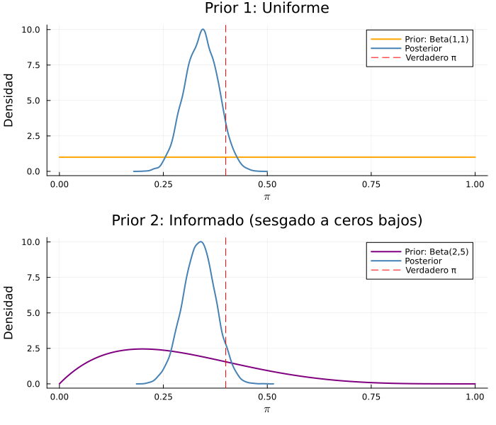

```julia
# ------------------------------------------------------------
# Celda 5: Gráficos comparativos de prior vs posterior (π)
# ------------------------------------------------------------
p1 = plot(layout=(2,1), size=(700,600))

# Prior 1 y posterior
plot!(p1[1], Beta(α1, β1), label="Prior: Beta(1,1)",
      xlabel=L"\pi", ylabel="Densidad", color=:orange, lw=2)
density!(p1[1], π_samples1, label="Posterior", color=:steelblue, lw=2)
vline!(p1[1], [π_true], label="Verdadero π", color=:red, linestyle=:dash)
title!(p1[1], "Prior 1: Uniforme")

# Prior 2 y posterior
plot!(p1[2], Beta(α2, β2), label="Prior: Beta(2,5)",
      xlabel=L"\pi", ylabel="Densidad", color=:purple, lw=2)
density!(p1[2], π_samples2, label="Posterior", color=:steelblue, lw=2)
vline!(p1[2], [π_true], label="Verdadero π", color=:red, linestyle=:dash)
title!(p1[2], "Prior 2: Informado (sesgado a ceros bajos)")

p1
```

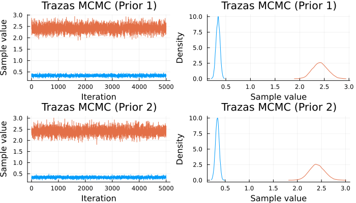

```julia
# ------------------------------------------------------------
# Celda 6: Trazas MCMC y convergencia
# ------------------------------------------------------------
p2 = plot(chain1, colordim=:parameter, title="Trazas MCMC (Prior 1)", size=(700,400))
p3 = plot(chain2, colordim=:parameter, title="Trazas MCMC (Prior 2)", size=(700,400))

plot(p2, p3, layout=(2,1))
```

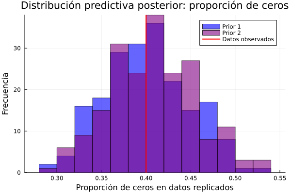

```julia
# ------------------------------------------------------------
# Celda 7: Comparación final: distribución predictiva posterior
# ------------------------------------------------------------
# Generar datos predictivos desde la posterior (usando 200 muestras aleatorias)
function simulate_zip_from_posterior(π_samples, λ_samples, n_sim=100)
    y_rep = []
    for _ in 1:n_sim
        idx = rand(1:length(π_samples))
        π_i = π_samples[idx]
        λ_i = λ_samples[idx]
        push!(y_rep, generate_zip(n, π_i, λ_i))
    end
    return y_rep
end

y_rep1 = simulate_zip_from_posterior(π_samples1, λ_samples1, 200)
y_rep2 = simulate_zip_from_posterior(π_samples2, λ_samples2, 200)

# Resumen: proporción de ceros en datos replicados
zeros_rep1 = [mean(y .== 0) for y in y_rep1]
zeros_rep2 = [mean(y .== 0) for y in y_rep2]

# Gráfico de comparación
p4 = histogram(zeros_rep1, label="Prior 1", alpha=0.6, color=:blue)
histogram!(p4, zeros_rep2, label="Prior 2", alpha=0.6, color=:purple)
vline!(p4, [mean(y_obs .== 0)], label="Datos observados", color=:red, lw=2)
xlabel!(p4, "Proporción de ceros en datos replicados")
ylabel!(p4, "Frecuencia")
title!(p4, "Distribución predictiva posterior: proporción de ceros")
p4
```

# **Caso 2: Rejection sampling. Ejemplo 1**

#### HIPERPARÁMETROS PERSONALIZABLES DEL PRIOR BETA

```julia
# Configurar semilla para reproducibilidad
Random.seed!(123)

# 1. DEFINIR HIPERPARÁMETROS PERSONALIZABLES DEL PRIOR BETA
println("Configuración del Prior Beta")
println("=============================")

# Parámetros del prior Beta - ¡Puedes modificar estos valores!
α_prior = 3.0    # Parámetro alpha del prior Beta
β_prior = 7.0    # Parámetro beta del prior Beta

println("Parámetros del Prior Beta:")
println("α = $α_prior, β = $β_prior")
prior_mean = α_prior/(α_prior + β_prior)
prior_var = (α_prior * β_prior) / ((α_prior + β_prior)^2 * (α_prior + β_prior + 1))
println("Media del prior: ", round(prior_mean, digits=4))
println("Varianza del prior: ", round(prior_var, digits=6))

prior_pi = Beta(α_prior, β_prior)
```

```
Configuración del Prior Beta
=============================
Parámetros del Prior Beta:
α = 3.0, β = 7.0
Media del prior: 0.3
Varianza del prior: 0.019091
```

```
Beta{Float64}(α=3.0, β=7.0)
```

#### SIMULAR DATOS

```julia
# 2. SIMULAR DATOS (ejemplo con inflación de ceros)
n = 100  # Número de observaciones
π_true = 0.3  # Probabilidad de cero inflado
λ_true = 1.5  # Tasa de la distribución Poisson para no ceros

println("\nSimulación de Datos")
println("===================")

# Generar datos: algunos ceros son inflados, otros provienen de Poisson
data = zeros(Int, n)
for i in 1:n
    if rand() < π_true
        data[i] = 0  # Cero inflado
    else
        data[i] = rand(Poisson(λ_true))  # Conteo de Poisson
    end
end

println(data[1:10])
```

```
Simulación de Datos
===================
[0, 2, 0, 1, 2, 4, 0, 0, 0, 4]
```

#### Estadisticas Descriptivas

```julia
# Calcular estadísticas descriptivas de los datos
n_zeros = sum(data .== 0)
prop_zeros = n_zeros / n
mean_nonzero = mean(data[data .> 0])

println("Número total de observaciones: $n")
println("Número de ceros: $n_zeros")
println("Proporción de ceros observada: ", round(prop_zeros, digits=4))
println("Proporción de ceros verdadera: $π_true")
println("Media de conteos no cero: ", round(mean_nonzero, digits=4))

# 3. FUNCIÓN DE VEROSIMILITUD para el modelo de inflación de ceros
function log_likelihood(π, data, λ_est=1.5)
    log_lik = 0.0
    for y in data
        if y == 0
            # Probabilidad de cero: inflado + Poisson(0)
            prob_zero = π + (1 - π) * exp(-λ_est)
            log_lik += log(prob_zero)
        else
            # Probabilidad de conteo no cero: (1 - π) * Poisson(y | λ)
            log_lik += log(1 - π) + logpdf(Poisson(λ_est), y)
        end
    end
    return log_lik
end
```

```
Número total de observaciones: 100
Número de ceros: 49
Proporción de ceros observada: 0.49
Proporción de ceros verdadera: 0.3
Media de conteos no cero: 2.2549
```

```
log_likelihood (generic function with 2 methods)
```

#### ALGORITMO DE MUESTREO POR RECHAZO

```julia
# 4. ALGORITMO DE MUESTREO POR RECHAZO
function rejection_sampling_with_tracking(data, prior, num_samples; λ_est=1.5)
    samples = Float64[]
    proposals = Float64[]
    accepted = Bool[]
    log_targets = Float64[]
    max_attempts = num_samples * 5000
    n_attempts = 0
    n_acceptances = 0

    # Encontrar el máximo de la densidad objetivo aproximado
    test_points = range(0.001, 0.999, length=100)
    log_target_values = [log_likelihood(π, data, λ_est) + logpdf(prior, π) for π in test_points]
    max_log_target = maximum(log_target_values)

    println("\nIniciando muestreo por rechazo...")
    println("Objetivo: $num_samples muestras")

    while length(samples) < num_samples && n_attempts < max_attempts
        n_attempts += 1

        # Proponer un valor de π del prior
        π_proposal = rand(prior)

        # Calcular log-densidad no normalizada
        log_prior_val = logpdf(prior, π_proposal)
        log_lik_val = log_likelihood(π_proposal, data, λ_est)
        log_target = log_lik_val + log_prior_val

        # Guardar información de la propuesta
        push!(proposals, π_proposal)
        push!(log_targets, log_target)

        # Generar uniforme en log-escala para comparación
        log_u = log(rand())

        # Aceptar si log_u <= log_target - max_log_target
        if log_u <= log_target - max_log_target
            push!(samples, π_proposal)
            push!(accepted, true)
            n_acceptances += 1
        else
            push!(accepted, false)
        end
    end

    acceptance_rate = n_acceptances / n_attempts
    println("Tasa de aceptación: $(round(acceptance_rate * 100, digits=2))%")
    println("Intentos totales: $n_attempts")
    println("Muestras obtenidas: $(length(samples))")

    if length(samples) < num_samples
        @warn "No se pudieron obtener todas las muestras deseadas."
    end

    return samples, proposals, accepted, log_targets, n_attempts
end
```

```
rejection_sampling_with_tracking (generic function with 1 method)
```

#### MUESTRAS DE LA POSTERIOR

```julia
# 5. GENERAR MUESTRAS DE LA POSTERIOR
num_samples = 50000
println("\nGenerando $num_samples muestras de la posterior...")
posterior_samples, all_proposals, accepted_status, log_target_values, attempts = rejection_sampling_with_tracking(data, prior_pi, num_samples)
```

```
Generando 50000 muestras de la posterior...

Iniciando muestreo por rechazo...
Objetivo: 50000 muestras
Tasa de aceptación: 35.63%
Intentos totales: 140333
Muestras obtenidas: 50000
```

[output not shown]

### Histograma de Resultados

```
==================================================
VISUALIZACIÓN PRINCIPAL DE RESULTADOS
==================================================
Tasa de aceptación: 35.6295%
```

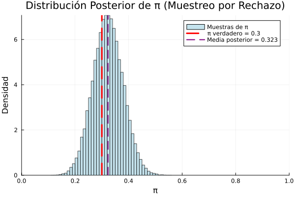

```julia
# 6. VISUALIZACIÓN DE RESULTADOS PRINCIPAL
println("\n" * "="^50)
println("VISUALIZACIÓN PRINCIPAL DE RESULTADOS")
println("="^50)

# Asegurar que posterior_samples exista
if !(@isdefined posterior_samples)
    posterior_samples = []   # evita UndefVarError
end

if !isempty(posterior_samples)
    acceptance_rate = length(posterior_samples) / attempts
    println("Tasa de aceptación: $(round(acceptance_rate*100, digits=4))%")

    # Histograma de la posterior
    p_main = histogram(
        posterior_samples,
        bins=50, normalize=true,
        label="Muestras de π", color=:lightblue, alpha=0.7,
        xlabel="π", ylabel="Densidad",
        title="Distribución Posterior de π (Muestreo por Rechazo)",
        xlim=(0, 1), legend=:topright
    )

    # Línea vertical con el valor verdadero
    vline!([π_true],
        label="π verdadero = $π_true",
        linewidth=3, color=:red, linestyle=:dash
    )

    # Media posterior
    posterior_mean = mean(posterior_samples)
    vline!([posterior_mean],
        label="Media posterior = $(round(posterior_mean, digits=3))",
        linewidth=2, color=:purple, linestyle=:dash
    )

    display(p_main)
else
    println("No se pudieron recolectar suficientes muestras para graficar.")
    println("⚠ Revisa tu código de muestreo para llenar posterior_samples.")
end
```

### Resultados

```julia
# 7. ANÁLISIS DE RESULTADOS DETALLADO
println("\nRESULTADOS BAYESIANOS DETALLADOS")
println("================================")
println("Prior: Beta(α=$α_prior, β=$β_prior)")

if !isempty(posterior_samples)
    posterior_mean = mean(posterior_samples)
    posterior_std = std(posterior_samples)
    posterior_ci = quantile(posterior_samples, [0.025, 0.975])

    println("\nDistribución Posterior:")
    println("Media posterior: ", round(posterior_mean, digits=4))
    println("Desviación estándar posterior: ", round(posterior_std, digits=4))
    println("Intervalo de credibilidad del 95%: ", round.(posterior_ci, digits=4))
    println("Valor verdadero de π: $π_true")

    # Calcular algunas probabilidades posteriores
    prob_gt_025 = sum(posterior_samples .> 0.25) / length(posterior_samples)
    prob_gt_03 = sum(posterior_samples .> 0.3) / length(posterior_samples)
    prob_gt_035 = sum(posterior_samples .> 0.35) / length(posterior_samples)

    println("\nProbabilidades posteriores:")
    println("P(π > 0.25) = ", round(prob_gt_025, digits=4))
    println("P(π > 0.30) = ", round(prob_gt_03, digits=4))
    println("P(π > 0.35) = ", round(prob_gt_035, digits=4))
end
```

[output not shown]

### DASHBOARD COMPLETO DE GRAFICOS DE CONTROL

```
==================================================
DASHBOARD COMPLETO DE ANÁLISIS
==================================================

Generando dashboard de gráficos...
```

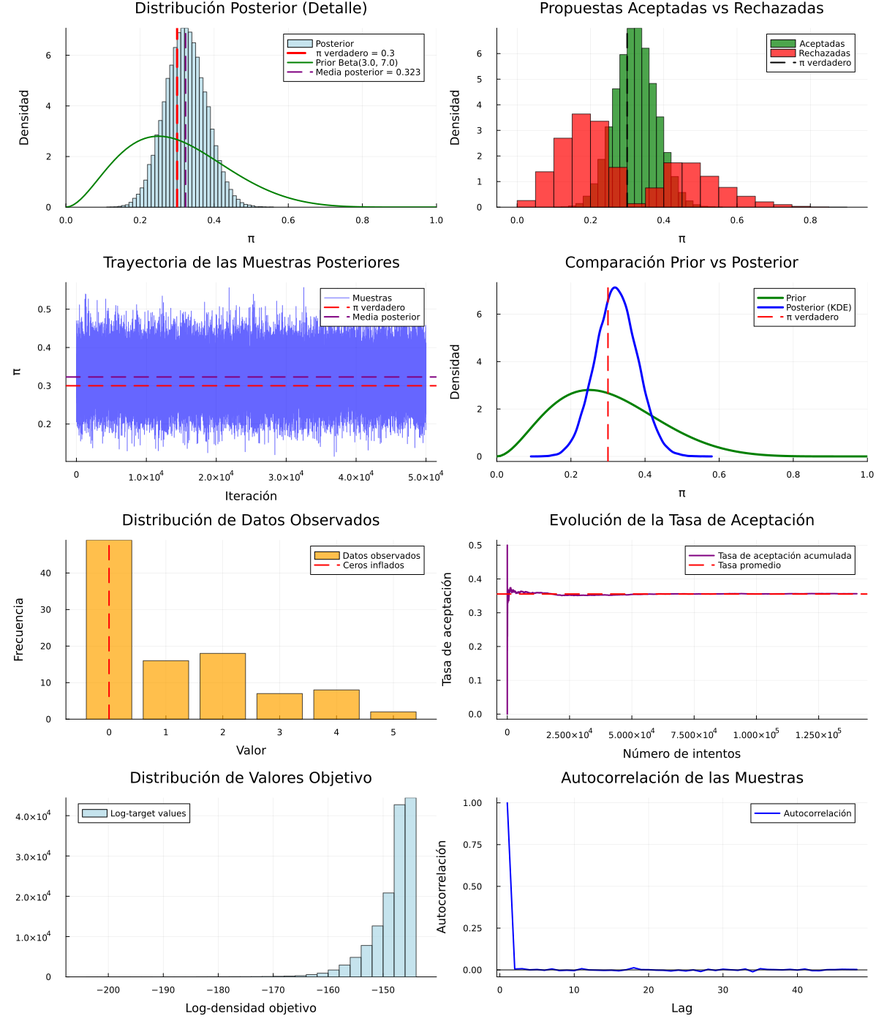

```julia
# 8. DASHBOARD COMPLETO DE GRÁFICOS ADICIONALES
println("\n" * "="^50)
println("DASHBOARD COMPLETO DE ANÁLISIS")
println("="^50)

if !isempty(posterior_samples)
    # Gráfico 1: Distribución posterior con prior y valor verdadero (versión extendida)
    p1 = histogram(posterior_samples, bins=50, normalize=true,
                   label="Posterior", color=:lightblue, alpha=0.7,
                   xlabel="π", ylabel="Densidad",
                   title="Distribución Posterior (Detalle)",
                   xlim=(0, 1))

    # Valor verdadero
    vline!([π_true], label="π verdadero = $π_true",
           linewidth=3, linecolor=:red, linestyle=:dash)

    # Distribución prior
    x_range = range(0, 1, length=100)
    prior_density = pdf.(prior_pi, x_range)
    plot!(x_range, prior_density, label="Prior Beta($α_prior, $β_prior)",
          linewidth=2, linecolor=:green)

    # Media posterior
    vline!([posterior_mean], label="Media posterior = $(round(posterior_mean, digits=3))",
           linewidth=2, linecolor=:purple, linestyle=:dash)

    # Gráfico 2: Histograma de propuestas aceptadas vs rechazadas
    accepted_proposals = all_proposals[accepted_status]
    rejected_proposals = all_proposals[.!accepted_status]

    p2 = histogram(accepted_proposals, bins=30, normalize=true, alpha=0.7,
                   label="Aceptadas", color=:green,
                   title="Propuestas Aceptadas vs Rechazadas",
                   xlabel="π", ylabel="Densidad")
    histogram!(rejected_proposals, bins=30, normalize=true, alpha=0.7,
               label="Rechazadas", color=:red)
    vline!([π_true], label="π verdadero", linewidth=2, linecolor=:black, linestyle=:dash)

    # Gráfico 3: Evolución de las muestras
    p3 = plot(posterior_samples, label="Muestras",
              xlabel="Iteración", ylabel="π",
              title="Trayectoria de las Muestras Posteriores",
              color=:blue, alpha=0.6)
    hline!([π_true], label="π verdadero", linewidth=2,
           linecolor=:red, linestyle=:dash)
    hline!([posterior_mean], label="Media posterior", linewidth=2,
           linecolor=:purple, linestyle=:dash)

    # Gráfico 4: Comparación Prior vs Posterior usando KDE
    p4 = plot(x_range, prior_density, label="Prior",
              linewidth=3, linecolor=:green,
              xlabel="π", ylabel="Densidad",
              title="Comparación Prior vs Posterior",
              legend=:topright, xlim=(0, 1))

    # Calcular densidad posterior usando KDE
    posterior_kde = kde(posterior_samples)
    plot!(posterior_kde.x, posterior_kde.density,
          label="Posterior (KDE)", linewidth=3, linecolor=:blue)
    vline!([π_true], label="π verdadero", linewidth=2,
           linecolor=:red, linestyle=:dash)

    # Gráfico 5: Distribución de los datos observados
    p5 = bar(countmap(data), label="Datos observados", color=:orange, alpha=0.7,
             xlabel="Valor", ylabel="Frecuencia",
             title="Distribución de Datos Observados")
    vline!([0], label="Ceros inflados", linewidth=2, linecolor=:red, linestyle=:dash)

    # Gráfico 6: Evolución de la tasa de aceptación
    cumulative_acceptance = cumsum(accepted_status) ./ (1:length(accepted_status))
    p6 = plot(cumulative_acceptance, label="Tasa de aceptación acumulada",
              xlabel="Número de intentos", ylabel="Tasa de aceptación",
              title="Evolución de la Tasa de Aceptación",
              color=:purple, linewidth=2)
    hline!([mean(cumulative_acceptance)], label="Tasa promedio",
            linewidth=2, linecolor=:red, linestyle=:dash)

    # Gráfico 7: Distribución de los valores objetivo (log-target)
    p7 = histogram(log_target_values, bins=50, label="Log-target values",
                   color=:lightblue, alpha=0.7,
                   xlabel="Log-densidad objetivo", ylabel="Frecuencia",
                   title="Distribución de Valores Objetivo")

    # Gráfico 8: Autocorrelación de las muestras
    if length(posterior_samples) > 100
        p8 = plot(autocor(posterior_samples), label="Autocorrelación",
                  xlabel="Lag", ylabel="Autocorrelación",
                  title="Autocorrelación de las Muestras",
                  color=:blue, linewidth=2)
        hline!([0], label="", linecolor=:black, linestyle=:solid)
    else
        p8 = plot([], [], title="No hay suficientes muestras para autocorrelación")
    end

    # Mostrar todos los gráficos en un dashboard
    println("\nGenerando dashboard de gráficos...")
    plot(p1, p2, p3, p4, p5, p6, p7, p8, layout=(4,2), size=(1200, 1400))

else
    println("No hay suficientes muestras para generar el dashboard completo.")
end
```

### Resumen Final

```julia
# 9. RESUMEN FINAL
println("\n" * "="^50)
println("RESUMEN FINAL DEL ANÁLISIS BAYESIANO")
println("="^50)
if !isempty(posterior_samples)
    println("• Prior utilizado: Beta(α=$α_prior, β=$β_prior)")
    println("• Media del prior: $(round(prior_mean, digits=4))")
    println("• Media posterior: $(round(posterior_mean, digits=4))")
    println("• Valor verdadero: $π_true")
    println("• Tasa de aceptación: $(round(acceptance_rate*100, digits=2))%")
    println("• El valor verdadero está en el IC 95%: ",
            π_true >= posterior_ci[1] && π_true <= posterior_ci[2] ? "SÍ" : "NO")
else
    println("No se pudieron obtener muestras suficientes para el análisis.")
end
```

[output not shown]

# **Caso 3: Rejection sampling: Ejemplo2**

```
Log(M_lik) encontrado: -146.30803144172387
Tasa de aceptación: 29.5814%
```

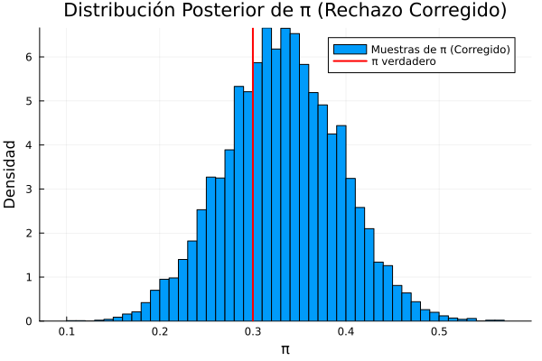

```julia
using Distributions
using Plots
using Random
using StatsBase # Se usa implícitamente por Plots/StatsBase para el histograma

# Configurar semilla para reproducibilidad
Random.seed!(123)

# 1. Definir hiperparámetros del prior Beta para π
α_star = 2.0
β_star = 5.0
prior_pi = Beta(α_star, β_star)

# 2. Simular datos
n = 100
π_true = 0.3
λ_true = 1.5 # Tasa real de la distribución Poisson
λ_est = 1.5 # Fijamos λ para la verosimilitud para simplificar el ejemplo

# Generar datos
data = zeros(n)
for i in 1:n
    if rand() < π_true
        data[i] = 0 # Cero inflado
    else
        data[i] = rand(Poisson(λ_true)) # Conteo de Poisson
    end
end

# 3. Función de verosimilitud (usando la λ_est fijada)
function log_likelihood(π, data)
    log_lik = 0.0
    for y in data
        if y == 0
            # P(y=0) = π + (1 - π) * P(Poisson(0) | λ)
            prob_zero = π + (1 - π) * exp(-λ_est)
            log_lik += log(prob_zero)
        else
            # P(y>0) = (1 - π) * P(Poisson(y | λ))
            log_lik += log(1 - π) + logpdf(Poisson(λ_est), y)
        end
    end
    return log_lik
end

# --- PASO DE CORRECCIÓN 1: ENCONTRAR LA COTA M ---
# Muestreo por Rechazo con Prior=Propuesta: M = max(Verosimilitud)
π_grid = 0.001:0.001:0.999
log_likelihood_values = [log_likelihood(π, data) for π in π_grid]
# Encontrar log(M_lik): el máximo de la log-verosimilitud
max_log_lik = maximum(log_likelihood_values)
println("Log(M_lik) encontrado: $max_log_lik")

# 4. Algoritmo de muestreo por rechazo (CORREGIDO)
function rejection_sampling_corrected(data, prior, num_samples, max_log_lik)
    samples = Float64[]
    # Aumentar el límite de intentos para asegurar la recolección
    max_attempts = 5_000_000
    n_attempts = 0

    while length(samples) < num_samples && n_attempts < max_attempts
        n_attempts += 1

        # Proponer un valor de π del prior (la propuesta g(π))
        π_proposal = rand(prior)

        # Calcular log-verosimilitud para la propuesta (Verosimilitud = f(π|y) / g(π))
        log_lik = log_likelihood(π_proposal, data)

        # Regla de aceptación CORRECTA:
        # Aceptar si log(U) <= log(Verosimilitud) - log(M_lik)
        log_u = log(rand())

        if log_u <= log_lik - max_log_lik
            push!(samples, π_proposal)
        end
    end

    # Manejo del error: si no se alcanzan las muestras, devuelve un mensaje
    if length(samples) < num_samples
        println("Advertencia: Solo se recolectaron $(length(samples)) muestras. Intenta aumentar max_attempts.")
    end

    return samples, n_attempts
end

# 5. Generar muestras de la posterior (Corregido)
num_samples = 10000
posterior_samples, attempts = rejection_sampling_corrected(data, prior_pi, num_samples, max_log_lik)

# 6. Visualizar resultados
if !isempty(posterior_samples)
    acceptance_rate = length(posterior_samples) / attempts
    println("Tasa de aceptación: $(round(acceptance_rate*100, digits=4))%")

    # El histograma ahora funcionará porque posterior_samples no está vacío
    histogram(posterior_samples, bins=50, normalize=true, label="Muestras de π (Corregido)",
              xlabel="π", ylabel="Densidad", title="Distribución Posterior de π (Rechazo Corregido)")
    vline!([π_true], label="π verdadero", linewidth=2, color=:red)
else
    println("No se pudieron recolectar suficientes muestras para graficar.")
end
```

# **Caso 4: GIBS Sampling**

```
Parámetros verdaderos:
β = [1.5, -2.0, 0.8]
σ² = 0.5
Condición de X: 3.1914010549926846

Estadísticas posteriores:
β1: media = 1.5537, std = 0.0544
β2: media = -2.0094, std = 0.0543
β3: media = 0.8256, std = 0.0478
σ²: media = 0.4936, std = 0.0515
```

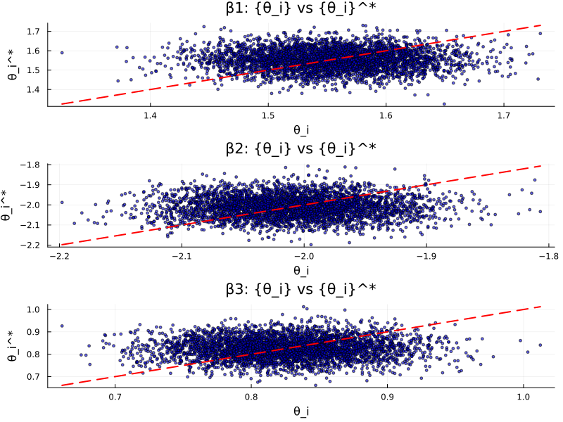

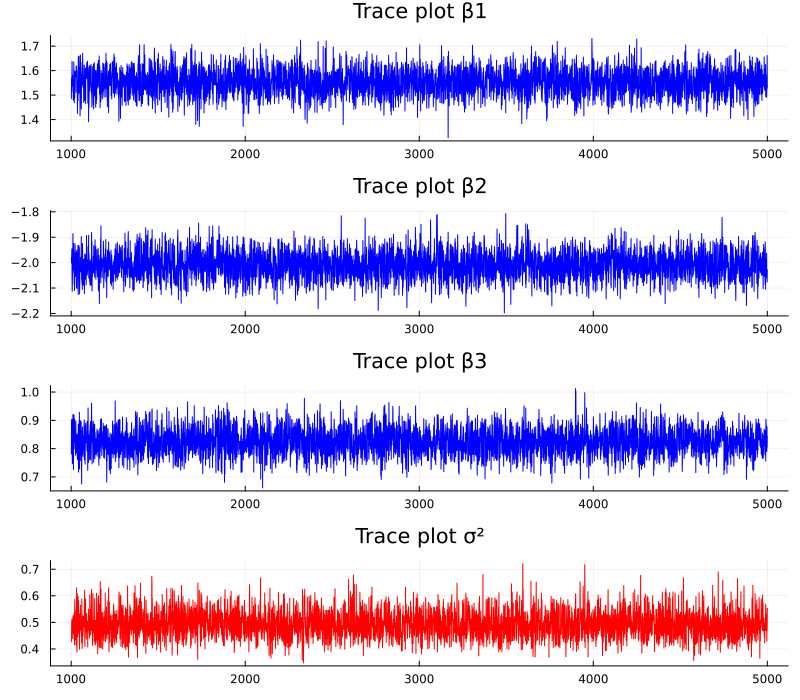

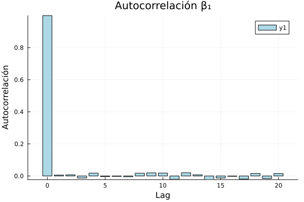

[output not shown]

```julia
using Distributions
using LinearAlgebra
using Plots
using Statistics
using Random

function gibbs_sampling_with_plots(X, y, m::Int, l::Int)

    n, d = size(X)

    # Inicialización de parámetros
    θ = zeros(d)  # β
    σ² = 1.0

    # Matrices para almacenar las muestras
    samples_β = zeros(m, d)
    samples_σ² = zeros(m)

    # Pre-cálculos útiles
    XtX = X'X
    Xty = X'y

    for i in 1:m
        # Paso 1: Muestrear β | σ², y ~ N(μ_β, Σ_β)
        # CORRECCIÓN: Usar una prior más informativa y asegurar definición positiva
        prior_precision = 0.1 * I  # Prior más fuerte para evitar matrices singulares
        Σ_β = inv(Symmetric(XtX/σ² + prior_precision))  # Usar Symmetric para asegurar hermiticidad
        μ_β = Σ_β * (Xty/σ²)

        # CORRECCIÓN: Verificar que la matriz sea definida positiva
        try
            θ = rand(MvNormal(μ_β, Σ_β))
        catch e
            # Si falla, usar una aproximación más estable
            if isa(e, PosDefException)
                # Agregar ruido pequeño a la diagonal para asegurar definición positiva
                Σ_β_corrected = Σ_β + 1e-6 * I
                θ = rand(MvNormal(μ_β, Σ_β_corrected))
            else
                rethrow(e)
            end
        end

        # Paso 2: Muestrear σ² | β, y ~ InverseGamma
        residuals = y - X * θ
        α_post = (n + 2)/2  # Parámetro de forma posterior ajustado
        β_post = dot(residuals, residuals)/2 + 1.0  # Parámetro de escala posterior más informativo

        σ² = rand(InverseGamma(α_post, β_post))

        # Almacenar muestras
        samples_β[i, :] = θ
        samples_σ²[i] = σ²
    end

    # Descartar burn-in
    β_post_burnin = samples_β[l+1:end, :]
    σ²_post_burnin = σ²_samples[l+1:end]

    # Crear gráficos
    create_plots(β_post_burnin, σ²_post_burnin, l, d)

    return β_post_burnin, σ²_post_burnin
end

function create_plots(β_samples, σ²_samples, burnin::Int, d::Int)
    """
    Crear gráficos de diagnóstico para el muestreo de Gibbs
    """

    m_post = size(β_samples, 1)
    iterations = (burnin+1):(burnin+m_post)

    # 1. Gráfico de {θ_i} vs {θ_i}^* (Trace plots para cada componente de β)
    plt_trace = plot(layout=(d,1), size=(800, 600), legend=false)

    for j in 1:d
        # θ_i vs θ_i^* (valores consecutivos)
        scatter!(plt_trace[j], β_samples[1:end-1, j], β_samples[2:end, j],
                markersize=2, alpha=0.6, color=:blue,
                title="β$j: {θ_i} vs {θ_i}^*",
                xlabel="θ_i", ylabel="θ_i^*")

        # Agregar línea de identidad
        min_val = minimum(β_samples[:,j])
        max_val = maximum(β_samples[:,j])
        plot!(plt_trace[j], [min_val, max_val], [min_val, max_val],
              line=:dash, color=:red, linewidth=2)
    end

    # 2. Trace plots tradicionales
    plt_traditional = plot(layout=(d+1,1), size=(800, 700), legend=false)

    for j in 1:d
        plot!(plt_traditional[j], iterations, β_samples[:, j],
              linewidth=1, color=:blue, title="Trace plot β$j")
    end

    plot!(plt_traditional[d+1], iterations, σ²_samples,
          linewidth=1, color=:red, title="Trace plot σ²")

    # 3. Gráfico de autocorrelación para el primer componente
    plt_acf = plot(layout=(1,1), size=(600, 400))
    lag = 20
    autocorrs = autocorrelation(β_samples[:, 1], lag)
    bar!(plt_acf, 0:lag, autocorrs, color=:lightblue,
         title="Autocorrelación β₁", xlabel="Lag", ylabel="Autocorrelación")

    # Mostrar todos los gráficos
    display(plt_trace)
    display(plt_traditional)
    display(plt_acf)

    return plt_trace, plt_traditional, plt_acf
end

function autocorrelation(x::Vector, max_lag::Int)
    """
    Calcular autocorrelación para una serie de tiempo
    """
    n = length(x)
    μ = mean(x)
    var_x = var(x)

    acf = zeros(max_lag + 1)

    for lag in 0:max_lag
        numerator = 0.0
        for i in 1:(n-lag)
            numerator += (x[i] - μ) * (x[i+lag] - μ)
        end
        acf[lag+1] = numerator / ((n - lag) * var_x)
    end

    return acf
end

# Versión más robusta del Gibbs sampling
function robust_gibbs_sampling(X, y, m::Int, l::Int)
    """
    Versión más robusta del Gibbs sampling
    """
    n, d = size(X)

    # Inicialización
    β = zeros(d)
    σ² = 1.0

    samples_β = zeros(m, d)
    samples_σ² = zeros(m)

    # Prior más informativo para evitar problemas numéricos
    prior_β_mean = zeros(d)
    prior_β_cov = 10.0 * I  # Prior más difuso

    for i in 1:m
        try
            # Muestrear β | σ², y
            Σ_β = inv(Symmetric(X'X/σ² + inv(prior_β_cov)))
            μ_β = Σ_β * (X'y/σ² + inv(prior_β_cov) * prior_β_mean)
            β = rand(MvNormal(μ_β, Σ_β))

            # Muestrear σ² | β, y
            residuals = y - X * β
            α_post = (n + 2)/2
            β_post = (dot(residuals, residuals) + 2)/2

            σ² = rand(InverseGamma(α_post, β_post))

            samples_β[i, :] = β
            samples_σ²[i] = σ²

        catch e
            # En caso de error, mantener los valores anteriores
            if i > 1
                samples_β[i, :] = samples_β[i-1, :]
                samples_σ²[i] = samples_σ²[i-1]
            end
        end
    end

    return samples_β[l+1:end, :], samples_σ²[l+1:end]
end

# Ejemplo de uso con datos simulados
function run_example()
    # Generar datos de ejemplo
    Random.seed!(123)
    n = 200
    d = 3

    # True parameters
    β_true = [1.5, -2.0, 0.8]
    σ²_true = 0.5

    # Generar datos bien condicionados
    X = hcat(ones(n), randn(n, d-1))
    # Asegurar que X'X sea bien condicionada
    X[:, 2] = X[:, 2] .+ 0.5 * X[:, 1]  # Agregar algo de correlación pero no perfecta
    X[:, 3] = X[:, 3] .- 0.3 * X[:, 2]

    y = X * β_true + randn(n) * sqrt(σ²_true)

    println("Parámetros verdaderos:")
    println("β = $β_true")
    println("σ² = $σ²_true")
    println("Condición de X: $(cond(X'X))")

    # Ejecutar Gibbs sampling robusto
    m = 5000
    burnin = 1000

    samples_β, samples_σ² = robust_gibbs_sampling(X, y, m, burnin)

    # Estadísticas de las muestras posteriores
    println("\nEstadísticas posteriores:")
    for j in 1:d
        β_post_mean = mean(samples_β[:, j])
        β_post_std = std(samples_β[:, j])
        println("β$j: media = $(round(β_post_mean, digits=4)), std = $(round(β_post_std, digits=4))")
    end

    σ²_post_mean = mean(samples_σ²)
    σ²_post_std = std(samples_σ²)
    println("σ²: media = $(round(σ²_post_mean, digits=4)), std = $(round(σ²_post_std, digits=4))")

    # Crear gráficos
    create_plots(samples_β, samples_σ², burnin, d)

    return samples_β, samples_σ²
end

# Ejecutar ejemplo
samples_β, samples_σ² = run_example()
```

# **Caso 5: Calculo de distribución $\lambda$ dado $\pi$**

## 1. Modelo

Sea una muestra $Y_1,\dots,Y_n$ con exceso de ceros. El modelo Zero-Inflated es:

$$ Y_i \sim \begin{cases} 0 & \text{con probabilidad } \pi,\\[4pt] \text{Poisson}(\lambda) & \text{con probabilidad } 1-\pi, \end{cases} $$

donde $\pi\in(0,1)$ y $\lambda>0$.

Definimos:

- $n =$ número de observaciones
- $n_0 = \sum_{i=1}^n \mathbf{1}(Y_i=0)$ número de ceros
- $S = \sum_{i=1}^n Y_i$ (**es $y_i$, no $x_i$**)

## 2. Verosimilitud y posterior (kernel)

La función de masa para una observación es:

$$ \Pr(Y_i=y_i\mid\pi,\lambda)= \begin{cases} \pi + (1-\pi)e^{-\lambda} & y_i=0,\\[4pt] (1-\pi)e^{-\lambda}\frac{\lambda^{y_i}}{y_i!} & y_i>0. \end{cases} $$

Ignorando constantes sin dependencia en $(\pi,\lambda)$, el kernel de la posterior es:

$$ K(\pi,\lambda\mid y)\propto \big[\pi+(1-\pi)e^{-\lambda}\big]^{n_0}\,(1-\pi)^{\,n-n_0}\, e^{-\lambda(n-n_0)}\,\lambda^{S}. $$

## 3. Distribuciones condicionales para Gibbs

### Condicional de $\pi$ dado $\lambda$

$$ \pi(\pi\mid y,\lambda)\ \propto\ \big[\pi+(1-\pi)e^{-\lambda}\big]^{n_0}\,(1-\pi)^{\,n-n_0}. $$

### Condicional de $\lambda$ dado $\pi$

> Esta es la que se solicitó obtener de forma matemática correcta:

$$ \pi(\lambda\mid y,\pi)\ \propto\ \big[\pi+(1-\pi)e^{-\lambda}\big]^{n_0}\, e^{-\lambda(n-n_0)}\,\lambda^{S}. $$

No es una Gamma → no tiene forma conjugada → se muestrea con **Rechazo**.

## 4. Estrategia de Rejection Sampling

Para simular $\theta$ desde su posterior condicional:

1. Elegir una propuesta $q(\theta)$ (usaremos Uniform).
2. Encontrar una constante $M$ tal que
   $$\pi(\theta\mid\cdot) \le M\,q(\theta).$$
3. Repetir:
   - Proponer $\theta' \sim q(\theta)$
   - Generar $u\sim U(0,1)$
   - Aceptar si
     $$u < \frac{\pi(\theta'|\cdot)}{M q(\theta')}$$

## 5. Algoritmo Gibbs (Rechazo en cada paso)

1. Inicializar $(\pi^{(0)},\lambda^{(0)})$
2. Para $t=0,\dots, T-1$
   - Muestrear $\pi^{(t+1)}\sim \pi(\pi\mid \lambda^{(t)}, y)$ por rechazo
   - Muestrear $\lambda^{(t+1)}\sim \pi(\lambda\mid \pi^{(t+1)}, y)$ por rechazo
3. Remover `burn-in` y obtener estimadores:
   - Media posterior
     $$\mathbb{E}[\pi] \approx \overline{\pi}, \qquad \mathbb{E}[\lambda] \approx \overline{\lambda}$$
   - Intervalos de credibilidad
     $$IC_{95\%}[\pi] = [Q_{0.025},Q_{0.975}],\quad IC_{95\%}[\lambda] = [Q_{0.025},Q_{0.975}]$$
   - Probabilidad de excedencia
     $$\Pr(\lambda>a) \approx \frac{1}{N}\sum\mathbf{1}(\lambda>a)$$

## 6. Se realizará este análisis en código Julia

```
Datos cargados:
n = 300,   ceros n0 = 111,   S = 393
```

```
"Condicionales graficadas"
```

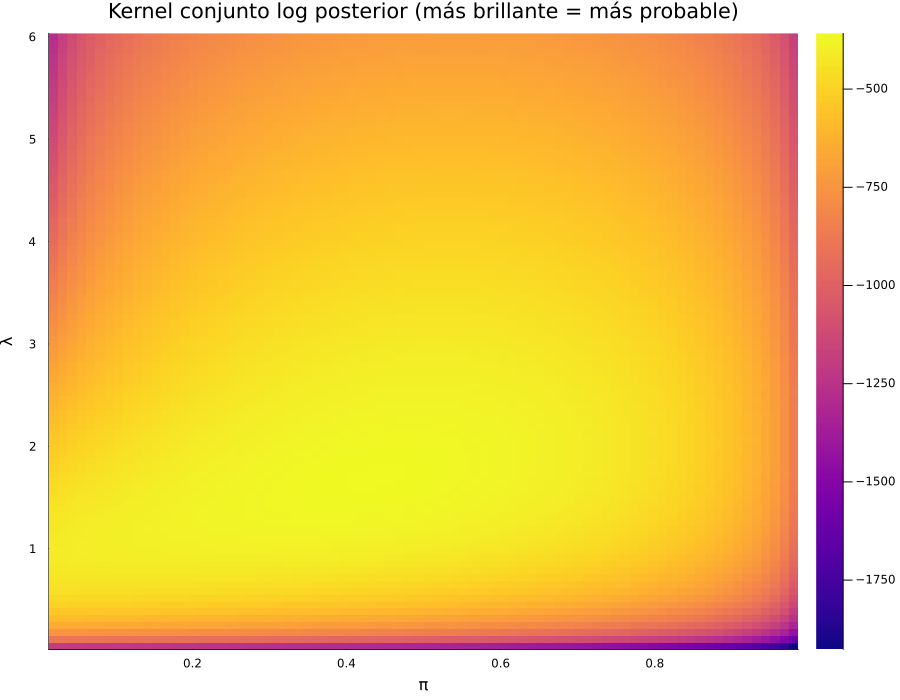

```
Iteración → 600
Iteración → 1200
Iteración → 1800
Iteración → 2400
Iteración → 3000
Iteración → 3600

Resumen posterior:
π media = 0.22983305327226816  mediana = 0.2305067153609961
λ media = 1.7063236530597412  mediana = 1.7034978332903425

IC95% π = [0.15412863625498952, 0.304811280300888]
IC95% λ = [1.5001647731692749, 1.9211248742159632]

Probabilidades de excedencia:
P(π>0.4) = 0.0
P(λ>2.0) = 0.0034982508745627187
```

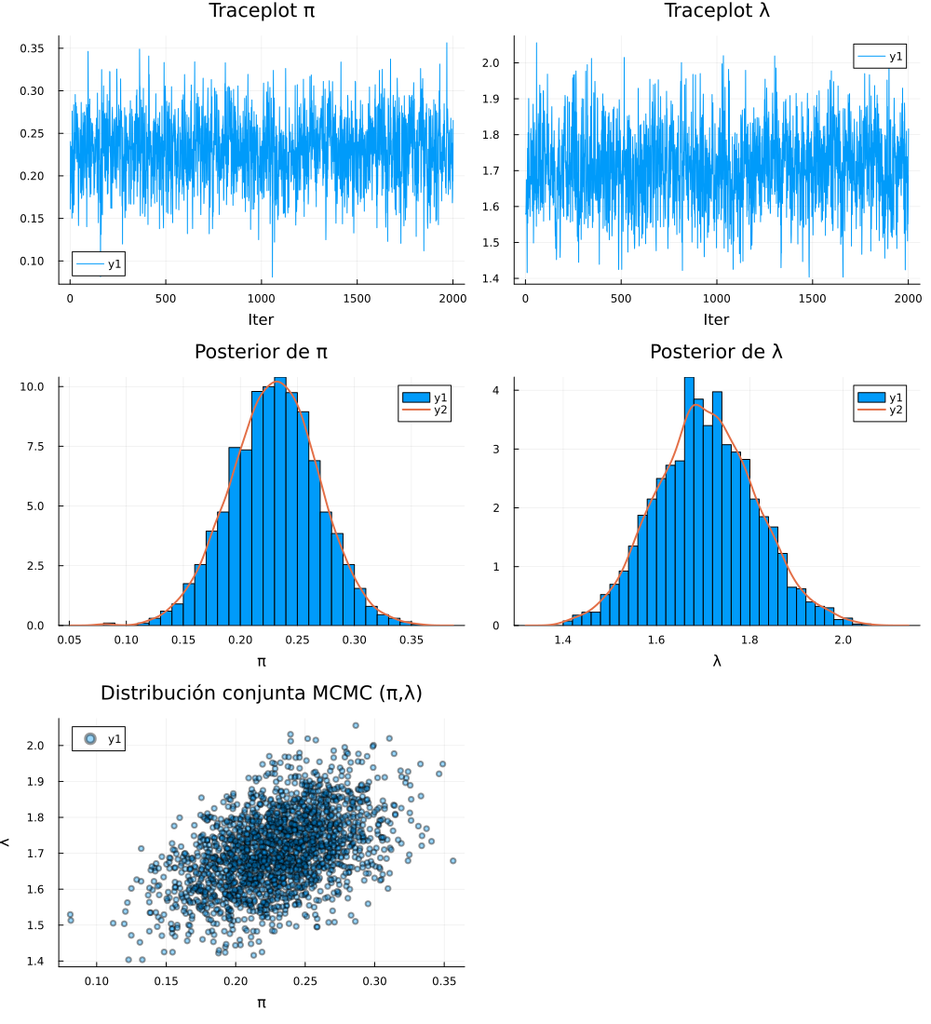

```julia
############################################################
###   Zero-Inflated Poisson MCMC Gibbs + Rechazo (Julia) ###
###   Ahora con análisis gráfico claro y didáctico        ###
############################################################

using Random, Distributions, Statistics, StatsBase
using Plots, KernelDensity, LinearAlgebra

Random.seed!(1)

############################################################
# 1. DATOS (puedes reemplazar por los reales)
############################################################

function generar_datos(n=300, π=0.25, λ=1.8)
    y = Int[]
    for i in 1:n
        rand() < π ? push!(y,0) : push!(y, rand(Poisson(λ)))
    end
    return y
end

y = generar_datos()
n = length(y)
n0 = count(==(0),y)
S  = sum(y)

println("\nDatos cargados:")
println("n = $n,   ceros n0 = $n0,   S = $S\n")


############################################################
# 2. Log-kernels condicionales
############################################################

EPS = 1e-12

logππ(π,λ) = (π<=0||π>=1) ? -Inf : n0*log(π+(1-π)*exp(-λ)) + (n-n0)*log(1-π)
logπλ(λ,π) = (λ<=0)      ? -Inf : n0*log(π+(1-π)*exp(-λ)) - λ*(n-n0) + S*log(λ)


############################################################
# A) GRAFICAR LAS CONDICIONALES
############################################################

λ_ref = 1.5    # valor elegido para visualizar π|λ
π_ref = 0.3    # valor elegido para visualizar λ|π

πgrid = range(0.001,0.999,length=300)
λgrid = range(0.0001,6,length=400)

πcond = exp.(logππ.(πgrid,λ_ref));  πcond ./= sum(πcond)
λcond = exp.(logπλ.(λgrid,π_ref));  λcond ./= sum(λcond)

pA = plot(πgrid, πcond, lw=2, title="Distribución condicional π | λ=$(λ_ref)",
          xlabel="π", ylabel="densidad", legend=false)

pB = plot(λgrid, λcond, lw=2, title="Distribución condicional λ | π=$(π_ref)",
          xlabel="λ", ylabel="densidad", legend=false)

plot(pA,pB,layout=(1,2),size=(900,350))
display("Condicionales graficadas")


############################################################
# B) Kernel conjunto para visualizar el paisaje posterior
############################################################

πG = range(0.02,0.98,length=80)
λG = range(0.05,6,length=90)
Z = [logππ(p,l) + logπλ(l,p) for p in πG, l in λG]  # Heatmap

pC = heatmap(πG,λG,Z', xlabel="π", ylabel="λ",
             title="Kernel conjunto log posterior (más brillante = más probable)",
             color=:plasma)
display(pC)


############################################################
# 3. FUNCIONES DE Rechazo + Gibbs
############################################################

function sample_pi(λ)
    logM = maximum(logππ.(πgrid,λ))
    while true
        p = rand()
        log(rand()) < logππ(p,λ)-logM && return p
    end
end

function sample_lambda(π;upper=6)
    logM = maximum(logπλ.(λgrid,π))
    while true
        l = rand()*upper
        log(rand()) < logπλ(l,π)-logM && return l
    end
end

function Gibbs(iter=4000, burn=2000)
    πs = zeros(iter); λs=zeros(iter)
    πs[1]=0.5; λs[1]=1.0

    for i in 1:iter-1
        πs[i+1] = sample_pi(λs[i])
        λs[i+1] = sample_lambda(πs[i+1])
        i%600==0 && println("Iteración → ",i)
    end

    return πs[burn:end], λs[burn:end]
end

πs,λs = Gibbs()

println("\nResumen posterior:")
println("π media = ",mean(πs),"  mediana = ",median(πs))
println("λ media = ",mean(λs),"  mediana = ",median(λs))
println("\nIC95% π = ",quantile(πs,[0.025,0.975]))
println("IC95% λ = ",quantile(λs,[0.025,0.975]),"\n")

println("Probabilidades de excedencia:")
println("P(π>0.4) = ",mean(πs .> 0.4))
println("P(λ>2.0) = ",mean(λs .> 2.0))


############################################################
# C) GRAFICOS DEL MCMC FINAL
############################################################

t1 = plot(πs, title="Traceplot π", xlabel="Iter")
t2 = plot(λs, title="Traceplot λ", xlabel="Iter")

h1 = histogram(πs, bins=40, norm=true,title="Posterior de π", xlabel="π")
kd1 = kde(πs); plot!(h1,kd1.x,kd1.density,lw=2)

h2 = histogram(λs, bins=40, norm=true,title="Posterior de λ", xlabel="λ")
kd2 = kde(λs); plot!(h2,kd2.x,kd2.density,lw=2)

sc = scatter(πs,λs,alpha=.4,ms=3,title="Distribución conjunta MCMC (π,λ)",
             xlabel="π",ylabel="λ")

plot(t1,t2,h1,h2,sc,layout=(3,2),size=(1000,1100))
```

```julia
Tambien se pueden graficar con lineas como paseo aleatoerio
```

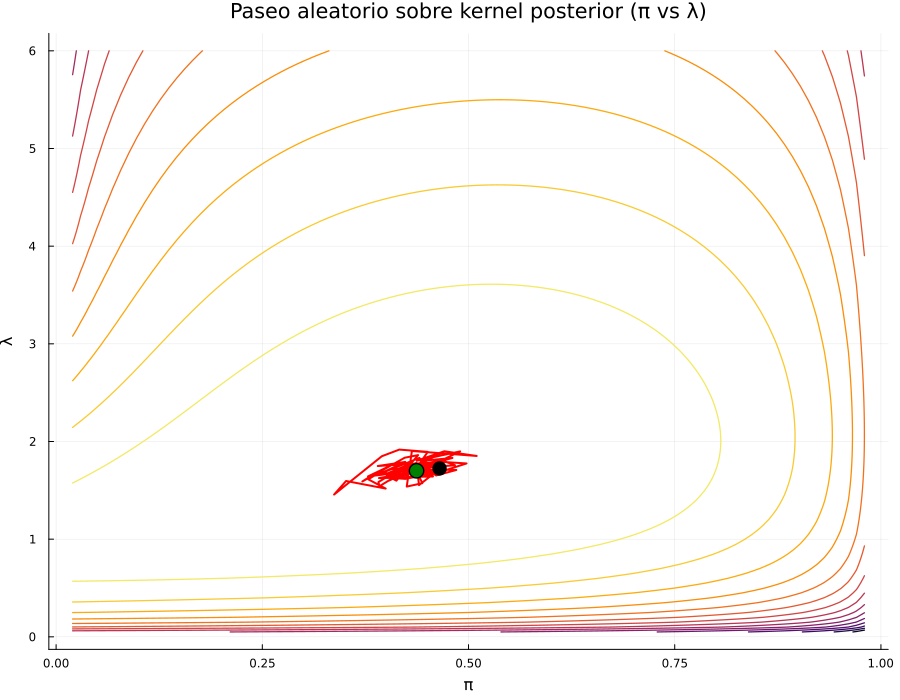

```julia
############################################################
# B) Paseo aleatorio sobre kernel posterior (CORREGIDO)
############################################################

πG = range(0.02,0.98,length=100)
λG = range(0.05,6,length=120)

# Matriz del kernel conjunto (log posterior)
Z = [logππ(p,l) + logπλ(l,p) for p in πG, l in λG]

# --- Contorno base ---
p_kernel = contour(πG, λG, Z', fill=false, lw=1.3,
    title="Paseo aleatorio sobre kernel posterior (π vs λ)",
    xlabel="π", ylabel="λ", legend=false)

# --- Inicializar caminante en el pico ---
idx = argmax(Z)          # retorna CartesianIndex
i0, j0 = Tuple(idx)      # extraemos coordenadas

rw_π = zeros(300); rw_λ=zeros(300)
rw_π[1] = πG[i0]
rw_λ[1] = λG[j0]

# --- Caminata tipo Metropolis sobre el paisaje posterior ---
σπ=0.05; σλ=0.25

for t in 2:length(rw_π)
    p_prop = clamp(rw_π[t-1] + σπ*randn(), 0.02,0.98)
    l_prop = clamp(rw_λ[t-1] + σλ*randn(), 0.05,6)

    logα = (logππ(p_prop,l_prop)+logπλ(l_prop,p_prop)) -
           (logππ(rw_π[t-1],rw_λ[t-1])+logπλ(rw_λ[t-1],rw_π[t-1]))

    if log(rand()) < logα
        rw_π[t]=p_prop; rw_λ[t]=l_prop
    else
        rw_π[t]=rw_π[t-1]; rw_λ[t]=rw_λ[t-1]
    end
end

# --- Dibujar recorrido ---
plot!(p_kernel, rw_π, rw_λ, lw=2, color=:red)
scatter!(p_kernel, [rw_π[1]],[rw_λ[1]],ms=8,color=:green,label="inicio")
scatter!(p_kernel, [rw_π[end]],[rw_λ[end]],ms=8,color=:black,label="fin")

display(p_kernel)
```

**By. Antonio Lam**